# Hi there

**I’m James**, I’m an experienced analyst, communicator and mentor, currently working in healthcare analytics and modelling. Before that, I worked in digital marketing but I’m also interested in human factors research, econometrics, polling and urban design.

**You can reach me on:** Email [LinkedIn](https://www.linkedin.com/in/james-kilgour/) [GitHub](https://github.com/james-kilgour)

## Experience

### Statistician/Information Analyst

*Public Health Scotland, Present*

- Exhibited patient clustering analysis at an NHS conference.
- Used SES models to forecast bed occupancy in Ayrshire community hospitals.
- Built zero-inflated regression models to analyse effect of staffing levels on patient safety.
- Made a Leaflet map showing health service accessibility via public/active transport using open data.
- Applied linear interpolation and calculus techniques to measure compliance against national care standards.
- See work GitHub account [here](https://github.com/jamesk-PHS).

### Senior Writer and Analyst

*CopyHouse, 2021-2024*

- Managed and led projects for highest margin accounts.
- Onboarded new staff as organisation grew 900% YOY.
- Achieved 97% client satisfaction score in annual survey.
- Expanded company services to include data analysis on web traffic, SEO strategy.

## Education

### MSc Applied Data Analytics

*University of the Highlands and Islands, Present*

- Achieved 78% module average so far with a maximum of 90%.
- Data Lab Scholarship recipient. Studying alongside full-time employment.
- Module specialisms include statistical modelling, machine learning and geospatial analysis in R/Python.

### BSc Data Science (Applied mathematics and statistics)

*The Open University, Paused*

- Studied alongside full-time employment, achieving a 2:1 in my second year.
- Modules include linear algebra, calculus, statistics and python programming.

### BSc Psychology

*Heriot-Watt University, Graduated with First Class Honours*

- Awarded Brotherton Project Prize, a departmental award given to the best student Honours project each academic year for my dissertation on cognitive factors within political messaging campaigns.
- Won Best Speaker at a British Psychological Society conference while exhibiting my research.
- Experience in experimental cognitive neuroscience research involving vulnerable demographics.

## Volunteering

*Guest speaker on statistics, analysis and R programming*

- Co-delivered professional learning workshops to teachers attending SSERC day courses.
- Guest speaker at Forth Valley College on data analysis techniques for HNC projects.

## Skills and Software

- *Statistics:* Data visualisation, multivariate analysis, power analysis, time-series analysis/forecasting, information governance & statistical disclosure control.
- *Programming:* Proficient in R, SQL, Git and HTML. Experienced in Python, LaTeX.
- *Software:* Proficient in R Markdown, GitHub, Excel, QGIS. Experienced in Tableau.
- *General:* 5+ years agency and start-up experience, project management, stakeholder engagement.

## Data viz examples

### A Sankey chart

Rankings in prevalence of long term conditions between age cohorts in Scotland. Source: [Disease Prevalence](https://publichealthscotland.scot/publications/general-practice-demographics-data-visualisation/general-practice-demographics-data-visualisation-up-to-31-december-2024/), Public Health Scotland.

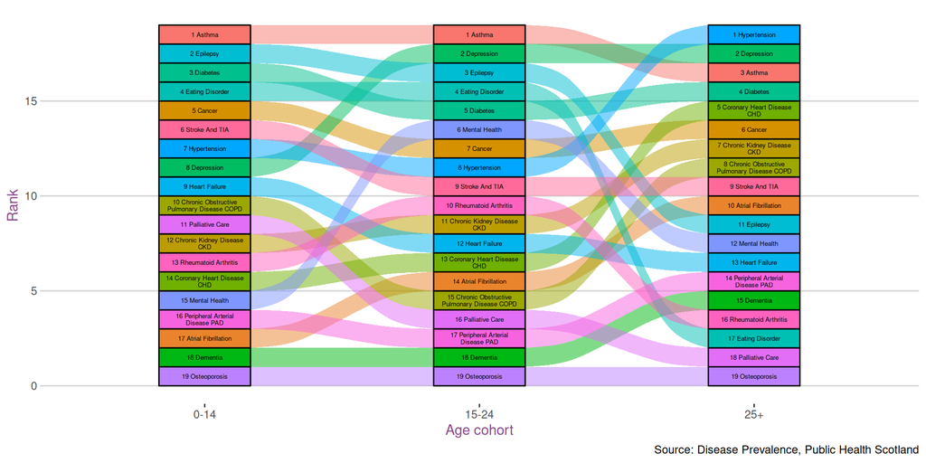

### An interactive map in `leaflet`

Use the map below to browse cycle paths in your local area. Map kindly provided Lucas Verney (Phyks on GitHub) via [CyclOSM](https://github.com/cyclosm) resource.

[interactive chart not shown]